# ComplexSimulation

2024-12-02

```r
library(MASS)
library(ggplot2)
library(tidyr)
library(dplyr)
library(SingleCellExperiment)
library(MANOVA.RM)
library(tibble)
library(tidyverse)
library(limma)
library(mclust)
```

## Proportion Difference by Simulations

In this section, I am providing 4 examples of simulation. Those simulation were simulated with only one response group, but with batch effect and cancer-like cell group. All simulations have moderate to high $\gamma \sim N(0,1)$. Note under the perfect ARI scenario, we only need sd = 0.3 to achieve power > 90%. Thus, sd = 1 simulates $\gamma$ with higher absolute values. The following simulations do not give the perfect ARI.

theta matrix is the inferred cell-by-topic proportion matrix from scSTMseq. In the following section, “summing” refers to adding each column of the theta matrix by sample, followed by normalization. “Max” refers to assigning a deterministic topic label to each cell by taking the maximum of each row.

```r
setwd("/proj/milovelab/wu/scLDAseq")
dir <- "/work/users/e/u/euphyw/scLDAseq/data/simulation/1MultiSample/SingleResponse/"
design <- "nSample20_nCellType10_Batch_CancerCell/"
scSTM <- "scSTM_Pooled_Content_Sample_Prevalence_Time/"
path = paste0(dir, design, scSTM)
files <- list.files(path)

r.file <- paste0("R/",list.files("R/"))
sapply(r.file, source)

name <- c("scSTM_1732766297_HighVar1.rds", "scSTM_1732766292_HighVar1.rds", # not significant
          "scSTM_1732766283_HighVar1.rds", "scSTM_1732766268_HighVar1.rds") # significant
files <- files[which(files %in% name)]
```

1. ARI
2. MANOVA.RM Results
3. Proportion difference between timepoints for inferred clusters, averaged across all samples
4. Proportion difference between timepoints for simulated data, averaged across all samples
5. Plot of proportion difference for each replicate by summing, difference using max proportion (use to calculate ARI), and the true proportion difference. In the plot, the grey represents the proportion difference for each replicate using “summing”. Blue dot is the true proportion difference, and red dot is the proportion difference using “max”.

```r
res <- lapply(files, function(file){
  scSTMobj <- readRDS(paste0(path, file))
  prop_diff(scSTMobj, nsims = 5)
})
saveRDS(res, file = "test.rds")
```

## Results

It is hard to identify any clear trend between the inferred difference (grey dots) and the truth (blue dots). When there exists significant proportion change, it seems the grey dots are more variable. It is obvious that using “max” gives a better proportion difference estimates, closer to the truth. Note that the matching between inferred topic and simulated truth is not 1-1. Topics were matched to the simulated group with the highest possibility.

### Simulation Example 1

```r
a <- res[[2]]
a$ARI
```

```
##   Cluster
## 0.9776622
```

```r
manova.res <- lapply(a$MANOVA, function(rep){
  x <- rep$Interaction
  x$resampling
})
manova.res <- do.call(rbind, manova.res)
rownames(manova.res) <- paste0("Replicate", 1:nrow(manova.res))
manova.res
```

```
##            paramBS (WTS) paramBS (MATS)
## Replicate1         0.113          0.065
```

#### Proportion Difference from scSTMseq

```r
bind_rows(a$scSTM_diff)
```

```
## # A tibble: 5 × 10
##        V1      V2       V3       V4       V5       V6      V7      V8       V9
##     <dbl>   <dbl>    <dbl>    <dbl>    <dbl>    <dbl>   <dbl>   <dbl>    <dbl>
## 1 -0.0240 -0.0128 -0.00224 -0.00721 -0.00762 -0.0143  0.0131  -0.0338 -0.00551
## 2 -0.0175 -0.0118  0.00113 -0.00893 -0.0118  -0.00314 0.0136  -0.0358 -0.0173
## 3 -0.0133 -0.0131  0.00537 -0.00523 -0.0155  -0.00571 0.00911 -0.0332 -0.0121
## 4 -0.0184 -0.0140 -0.00466 -0.0167  -0.0102  -0.00544 0.0181  -0.0287 -0.00318
## 5 -0.0194 -0.0141  0.00552 -0.00676 -0.0206  -0.00582 0.0106  -0.0248 -0.00999
## # ℹ 1 more variable: V10 <dbl>
```

#### Proportion Difference from Truth

```r
a$sims_diff
```

```
## # A tibble: 1 × 11
##   Response   Group1  Group2 Group3  Group4 Group5  Group6 Group7  Group8  Group9
##   <chr>       <dbl>   <dbl>  <dbl>   <dbl>  <dbl>   <dbl>  <dbl>   <dbl>   <dbl>
## 1 t1       -0.00337 -0.0727  0.246 -0.0309 -0.112 -0.0215 0.0415 -0.0469 5.19e-4
## # ℹ 1 more variable: Group10 <dbl>
```

#### Visualization

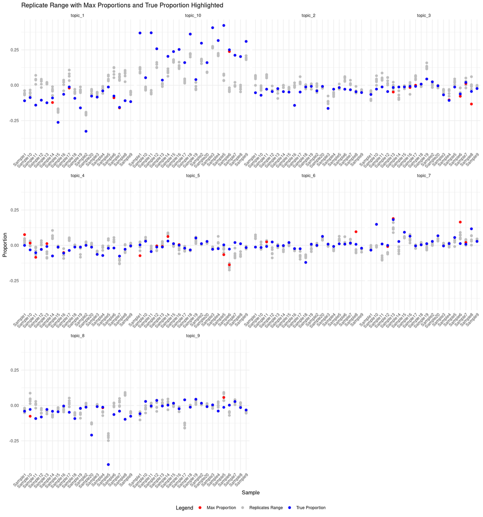

```r
a$plot
```

### Simulation Example 2

ARI is 0.91. The resampling p-values are boardline significant. In simulation, the highest change at 0.15, where the inferred clustering only have the highest difference at -0.03, which is lower than the previous example.

```r
a <- res[[1]]
a$ARI
```

```
##   Cluster
## 0.9075122
```

```r
manova.res <- lapply(a$MANOVA, function(rep){
  x <- rep$Interaction
  x$resampling
})
manova.res <- do.call(rbind, manova.res)
rownames(manova.res) <- paste0("Replicate", 1:nrow(manova.res))
manova.res
```

```
##            paramBS (WTS) paramBS (MATS)
## Replicate1         0.324          0.059
```

#### Proportion Difference from scSTMseq

```r
bind_rows(a$scSTM_diff)
```

```
## # A tibble: 5 × 10
##        V1      V2      V3       V4      V5      V6      V7       V8        V9
##     <dbl>   <dbl>   <dbl>    <dbl>   <dbl>   <dbl>   <dbl>    <dbl>     <dbl>
## 1 -0.0343 -0.0265 0.0124  0.00975  -0.0221 0.00920 0.0112  0.00463  -0.00607
## 2 -0.0304 -0.0284 0.0126  0.000687 -0.0156 0.00759 0.00834 0.0102   -0.00435
## 3 -0.0326 -0.0159 0.00610 0.00924  -0.0256 0.00933 0.00769 0.00567  -0.00382
## 4 -0.0357 -0.0170 0.0127  0.00548  -0.0173 0.0102  0.00306 0.00355  -0.00500
## 5 -0.0249 -0.0233 0.0105  0.00619  -0.0179 0.0112  0.00317 0.000141 -0.000815
## # ℹ 1 more variable: V10 <dbl>
```

#### Proportion Difference from Truth

```r
a$sims_diff
```

```
## # A tibble: 1 × 11
##   Response   Group1 Group2  Group3 Group4 Group5 Group6  Group7  Group8  Group9
##   <chr>       <dbl>  <dbl>   <dbl>  <dbl>  <dbl>  <dbl>   <dbl>   <dbl>   <dbl>
## 1 t1       0.000218 0.0291 0.00854 0.0459 0.0302  0.150 -0.0738 -0.0836 -0.0782
## # ℹ 1 more variable: Group10 <dbl>
```

#### Visualization

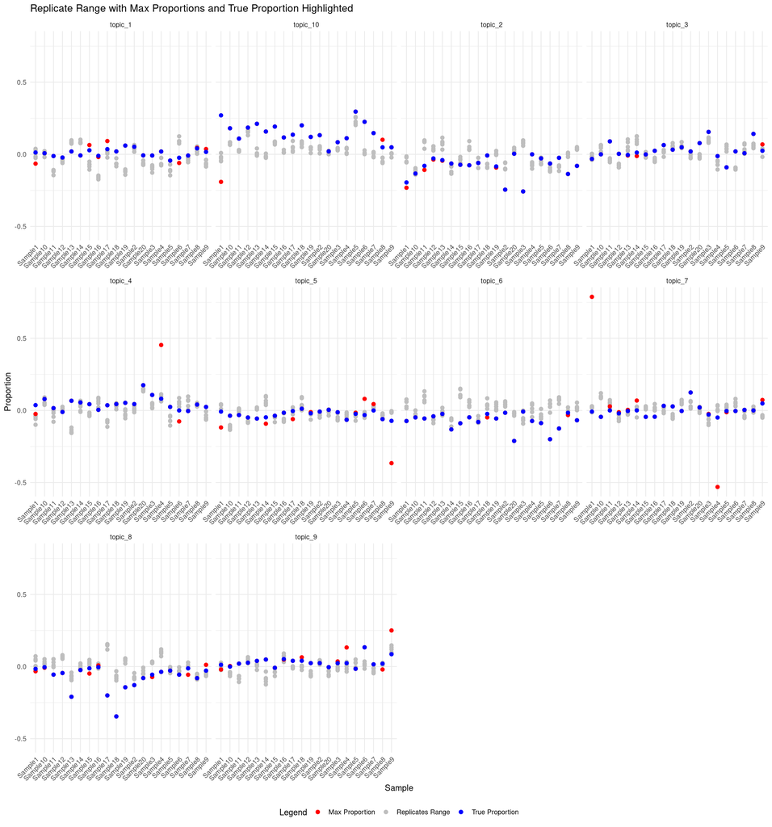

```r
a$plot
```

### Simulation Example 3

```r
a <- res[[3]]
a$ARI
```

```
## Cluster
## 0.89785
```

```r
manova.res <- lapply(a$MANOVA, function(rep){
  x <- rep$Interaction
  x$resampling
})
manova.res <- do.call(rbind, manova.res)
rownames(manova.res) <- paste0("Replicate", 1:nrow(manova.res))
manova.res
```

```
##            paramBS (WTS) paramBS (MATS)
## Replicate1         0.309          0.267
```

#### Proportion Difference from scSTMseq

```r
bind_rows(a$scSTM_diff)
```

```
## # A tibble: 5 × 10
##       V1      V2      V3      V4        V5       V6        V7      V8      V9
##    <dbl>   <dbl>   <dbl>   <dbl>     <dbl>    <dbl>     <dbl>   <dbl>   <dbl>
## 1 0.0441 0.0164  0.00120 -0.0279 -0.00716  -0.00858 -0.00371  0.0130  -0.0132
## 2 0.0357 0.00839 0.00507 -0.0228 -0.0110   -0.00961  0.00430  0.0168  -0.0170
## 3 0.0390 0.0143  0.00518 -0.0261 -0.00246  -0.00583  0.000235 0.00358 -0.0180
## 4 0.0413 0.0123  0.00820 -0.0247 -0.00569   0.00141 -0.00318  0.00453 -0.0216
## 5 0.0391 0.0172  0.00293 -0.0248 -0.000106 -0.00113 -0.0116   0.00484 -0.0200
## # ℹ 1 more variable: V10 <dbl>
```

#### Proportion Difference from Truth

```r
a$sims_diff
```

```
## # A tibble: 1 × 11
##   Response Group1  Group2 Group3  Group4  Group5 Group6 Group7  Group8  Group9
##   <chr>     <dbl>   <dbl>  <dbl>   <dbl>   <dbl>  <dbl>  <dbl>   <dbl>   <dbl>
## 1 t1       0.0876 -0.0312 0.0266 -0.0482 -0.0890 0.0166 0.0938 0.00790 -0.0465
## # ℹ 1 more variable: Group10 <dbl>
```

#### Visualization

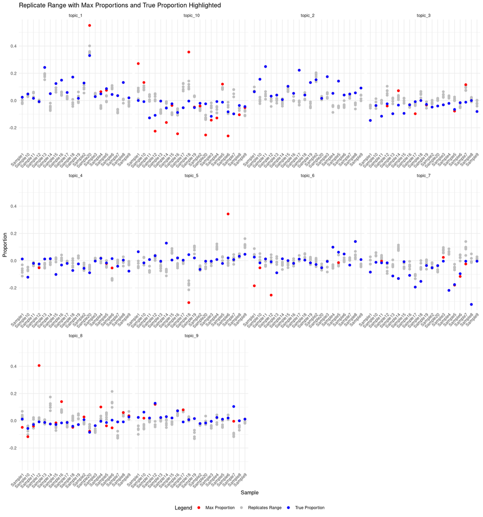

```r
a$plot
```

### Simulation Example 4

ARI is 0.958, and the proportion change is not significant.

```r
a <- res[[4]]
a$ARI
```

```
##   Cluster
## 0.9584145
```

```r
manova.res <- lapply(a$MANOVA, function(rep){
  x <- rep$Interaction
  x$resampling
})
manova.res <- do.call(rbind, manova.res)
rownames(manova.res) <- paste0("Replicate", 1:nrow(manova.res))
manova.res
```

```
##            paramBS (WTS) paramBS (MATS)
## Replicate1         0.096           0.12
```

#### Proportion Difference from scSTMseq

```r
bind_rows(a$scSTM_diff)
```

```
## # A tibble: 5 × 10
##        V1       V2       V3     V4      V5       V6       V7     V8      V9
##     <dbl>    <dbl>    <dbl>  <dbl>   <dbl>    <dbl>    <dbl>  <dbl>   <dbl>
## 1 -0.0209 -0.0123  -0.00887 0.0357 0.0119  -0.00823 -0.00589 0.0151 0.00596
## 2 -0.0194 -0.00878 -0.00633 0.0395 0.00694 -0.0129  -0.00244 0.0210 0.00288
## 3 -0.0204 -0.0144  -0.00255 0.0381 0.00377 -0.00792 -0.00345 0.0204 0.00854
## 4 -0.0238 -0.0176  -0.00107 0.0421 0.0107  -0.00654 -0.00476 0.0125 0.00475
## 5 -0.0244 -0.0132  -0.0123  0.0421 0.0117  -0.00752  0.00192 0.0127 0.00739
## # ℹ 1 more variable: V10 <dbl>
```

#### Proportion Difference from Truth

```r
a$sims_diff
```

```
## # A tibble: 1 × 11
##   Response  Group1  Group2 Group3 Group4  Group5  Group6 Group7 Group8  Group9
##   <chr>      <dbl>   <dbl>  <dbl>  <dbl>   <dbl>   <dbl>  <dbl>  <dbl>   <dbl>
## 1 t1       -0.0678 -0.0332  0.147 0.0533 -0.0819 -0.0677 0.0981 0.0176 -0.0293
## # ℹ 1 more variable: Group10 <dbl>
```

#### Visualization

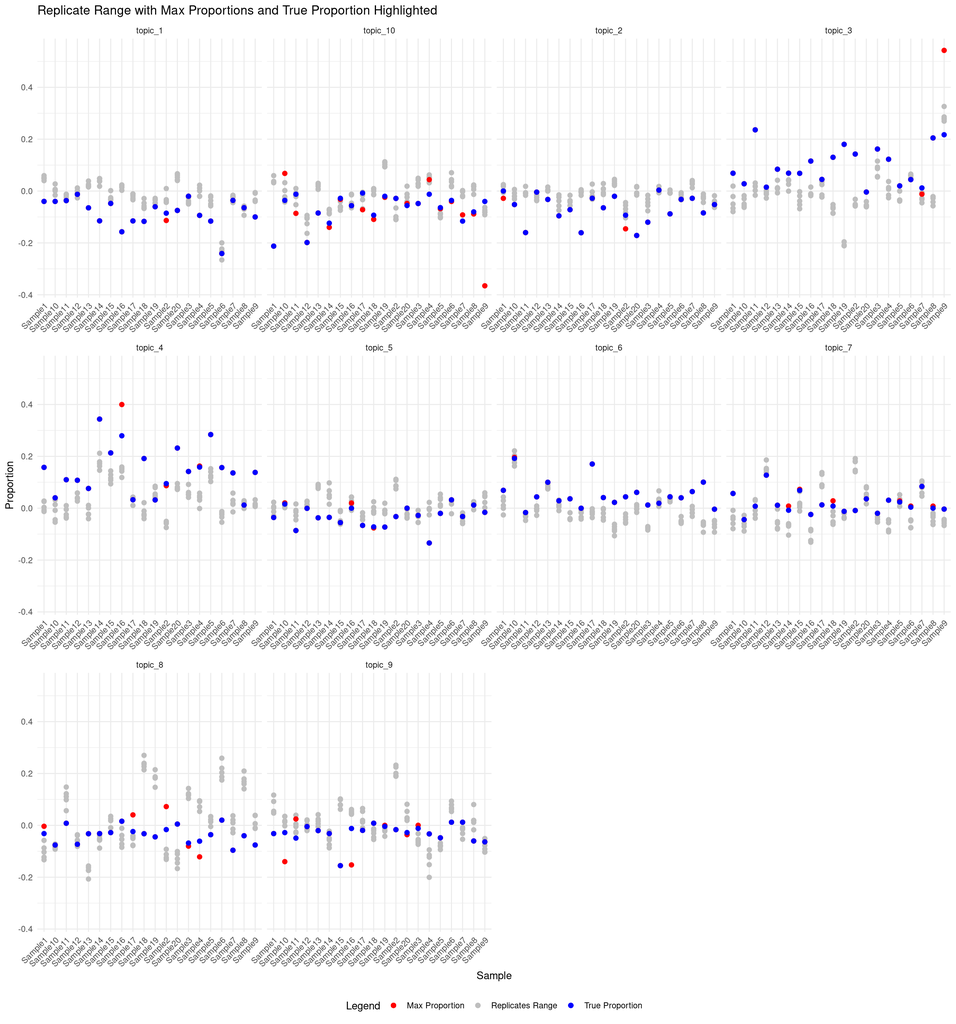

```r
a$plot
```